# 心的回転 (mental rotation)

Risako Shirai

2018/8/2

# レポート完成までの道のり

このページでは，Rmarkdownを使用して心的回転課題の簡単なレポートを作成することを目標にその方法を説明していきます！まず，Rmarkdownを使用するためには，以下の3つのツールが必要となります。このページでは，Rstudio上でコードを走らせることを想定して紹介をしますので，以下に加えて[Rstudioもインストール](https://www.rstudio.com/products/rstudio/download/)することをお勧めします。

- [R](https://www.r-project.org)
- [rmarkdownパッケージ](https://rmarkdown.rstudio.com)
- [pandoc](https://pandoc.org)

# レポート用のファイルを作成する。

① まず，Rmarkdown用のファイルを作成します。以下の赤枠内のボタンを押すと，「R markdown…」という項目がるので，そこをクリックします。

[figure not shown]

Figure 1

② そうすると，以下のようなウィンドウが開きます。Titleをつけ，「OK」で先に進みます。  
（Titleは後から変更可能です）

[figure not shown]

③ これで準備完了です。以下の赤枠部分に文章や書いていくことができます。点線で囲まれた箇所には，はじめに設定したこのファイルのtitle，author，data，outputに関する情報が明記されています。

[figure not shown]

Figure 3

④ 赤枠内が灰色の箇所と白色の箇所に分かれているのが分かるかと思います。灰色の箇所は主にコードを記述する箇所，白色の箇所は文章として表示したいものを記述する箇所になっています。

⑤ この状態で「knit」のボタンを押すと（図の矢印部分）， html形式でレポートの作成をおこなってくれます。デフォルトで文章やコードが書かれているので，自分のレポートを作成する前であっても，「knit」を押すだけで，Rmarkdownで作成したレポートがどのような見えを提供してくれるのかが分かります。

[figure not shown]

⑥ さて，ここからオリジナルでレポートを作成していきます。今回ははじめにも記述した通り，心的回転の簡単なレポートを作成する，ということが目標ですから，まず，序論となる箇所の文章をRmarkdownで書いていきます。

## 文章を書く

① Title, author, date, outputの情報が書かれている点線箇所の中はいじらずに，点線より下の位置から文章を打ち込んでいきます。章立てしたい時には，シャープ（#）をタイトルの前に置くとその部分のみ自動的に強調してくれます。シャープの数が1つの場合は大見出し，2つの場合は小見出しといった具合で表現してくれます。

[figure not shown]

Figure 5

② 使用する機会は多くないかもしれませんが，レポート内でリンクをつける方法につついてもご紹介します。以下のように，文章の中でリンクをつけたい箇所を “[]” でくくり，その後に 半かっこをつけて“[id]” と打ち込みます。そして，適当な場所に半かっこで[id]と打ち，その後に http://~ と明記しておくと，そのURL先へのリンクを作成することができます。なお， リンクをつける箇所の後に書いた“id” は，URLの前につけている参照コード（“id”）と一緒であれば何でも構いません。

[figure not shown]

Figure 6

③ ここまでで書いた文章をKnitしてみて，どのような見えになっているか確認します。 はじめに行ったのと同じように，Knitのボタンを押します。

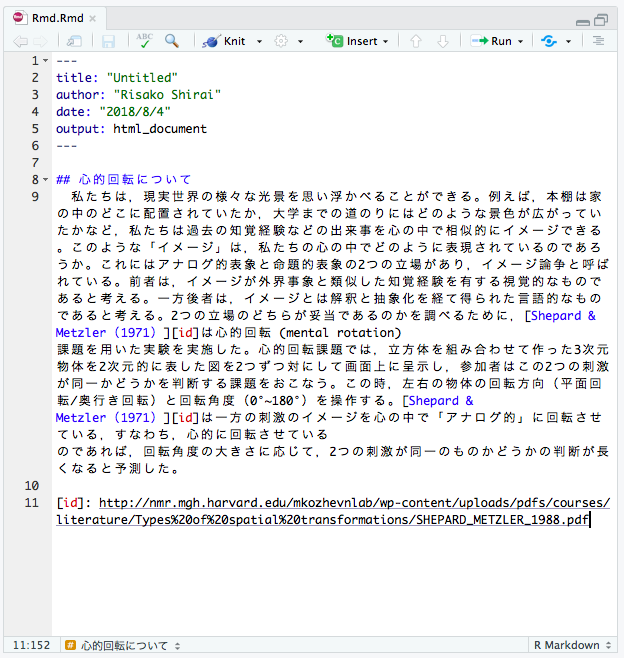

Figure 7

④ うまく表示されているようです。  
これで心的回転の概要を書くことができました。

[figure not shown]

Figure 8